# Exploring Data with Graphs

STA9661

## Outline

- How to visualise your data using ggplot2.
  - ggplot2 is elegant and versatile.
  - ggplot2 implements the **grammar of graphics**.

## Why ggplot2?

See [Why use ggplot2](https://github.com/tidyverse/ggplot2/wiki/Why-use-ggplot2) page.

## Why visualization?

> “The simple graph has brought more information to the data analyst’s mind than any other device.” — John Tukey

## Examples

[Hans Rosling’s 200 Countries, 200 Years, 4 Minutes - The Joy of Stats - BBC Four](https://youtu.be/jbkSRLYSojo)

[An Extremely Detailed Map of the 2016 US Presidential Election](https://www.nytimes.com/interactive/2018/upshot/election-2016-voting-precinct-maps.html#10.00/43.142/-89.860)

## First steps–ask questions

> “An approximate answer to the right problem is worth a good deal more than an exact answer to an approximate problem.” — John Tukey

## (Crudely summarized) steps to produce visualization

1. Find a question to answer
2. Transform and explore the data
3. Produce visualization

## The `mpg` data frame

- Let’s start with the `mpg` **data frame** found in ggplot2 (aka `ggplot2::mpg`).
- `mpg` contains observations collected by the US Environment Protection Agency on 38 models of cars.

## Questions

- Do cars with big engines use more fuel than cars with small engines?
- What does the relationship between engine size and fuel efficiency look like? Is it positive? Negative? Linear? Nonlinear?

## The `mpg` data frame

```r
mpg
```

```
## # A tibble: 234 x 11
##    manufacturer model displ  year   cyl trans drv     cty   hwy fl    class
##    <chr>        <chr> <dbl> <int> <int> <chr> <chr> <int> <int> <chr> <chr>
##  1 audi         a4      1.8  1999     4 auto… f        18    29 p     comp…
##  2 audi         a4      1.8  1999     4 manu… f        21    29 p     comp…
##  3 audi         a4      2    2008     4 manu… f        20    31 p     comp…
##  4 audi         a4      2    2008     4 auto… f        21    30 p     comp…
##  5 audi         a4      2.8  1999     6 auto… f        16    26 p     comp…
##  6 audi         a4      2.8  1999     6 manu… f        18    26 p     comp…
##  7 audi         a4      3.1  2008     6 auto… f        18    27 p     comp…
##  8 audi         a4 q…   1.8  1999     4 manu… 4        18    26 p     comp…
##  9 audi         a4 q…   1.8  1999     4 auto… 4        16    25 p     comp…
## 10 audi         a4 q…   2    2008     4 manu… 4        20    28 p     comp…
## # … with 224 more rows
```

## Among the variables in `mpg` are:

1. `displ`, a car’s engine size, in litres.
2. `hwy`, a car’s fuel efficiency on the highway, in miles per gallon (mpg). A car with a low fuel efficiency consumes more fuel than a car with a high fuel efficiency when they travel the same distance.

## Creating a ggplot

To plot `mpg`, run this code to put `displ` on the x-axis and `hwy` on the y-axis:

```r
ggplot(data = mpg) +
  geom_point(mapping = aes(x = displ, y = hwy))
```

## What do we learn?

- Begin a plot with the function `ggplot()`.
  - `ggplot()` creates a coordinate system that you can add layers to.
  - The first argument of `ggplot()` is the dataset to use in the graph.
- Complete your graph by adding one or more layers to `ggplot()`.
- The function `geom_point()` adds a layer of points to your plot.
- geom function takes a `mapping` argument: how variables in your dataset are mapped to visual properties.
- The `mapping` argument is always paired with `aes()`.

## A graphing template

```r
ggplot(data = <DATA>) +
  <GEOM_FUNCTION>(mapping = aes(<MAPPINGS>))
```

## Mappings

- In the plot below, one group of points seems to fall outside of the linear trend. How are they different?
- How can you explain these cars?

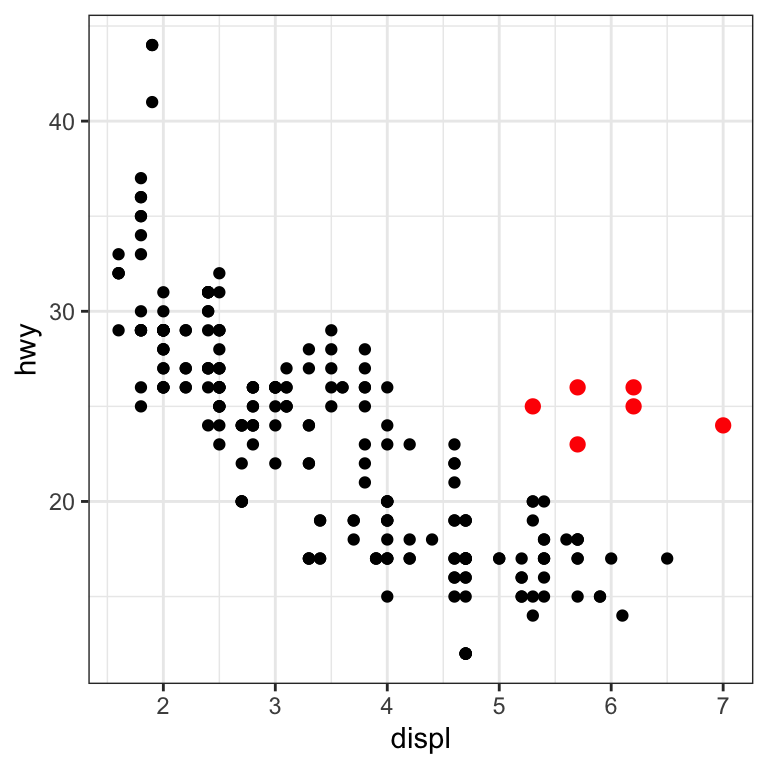

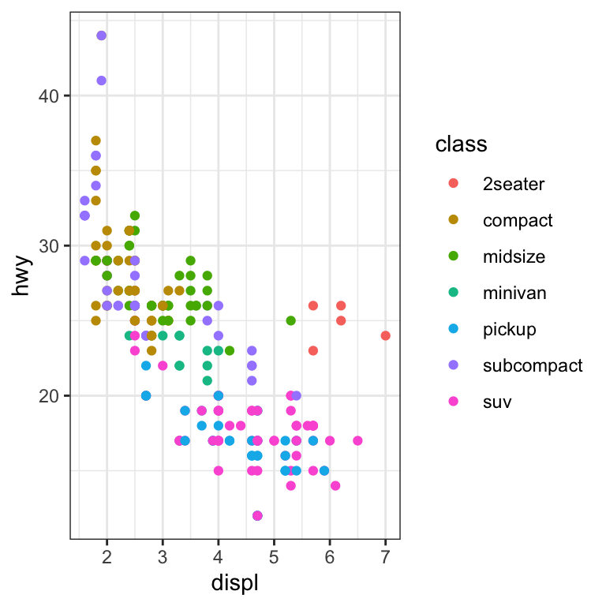

```r
ggplot(data = mpg) +
  geom_point(mapping = aes(x = displ, y = hwy, color = class))
```

(If you prefer British English, like Hadley, you can use `colour` instead of `color`.)

## There are more than one mapping

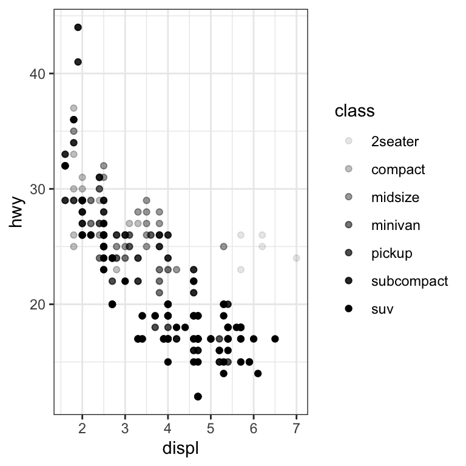

```r
ggplot(data = mpg) +
  geom_point(mapping = aes(x = displ, y = hwy, alpha = class))
```

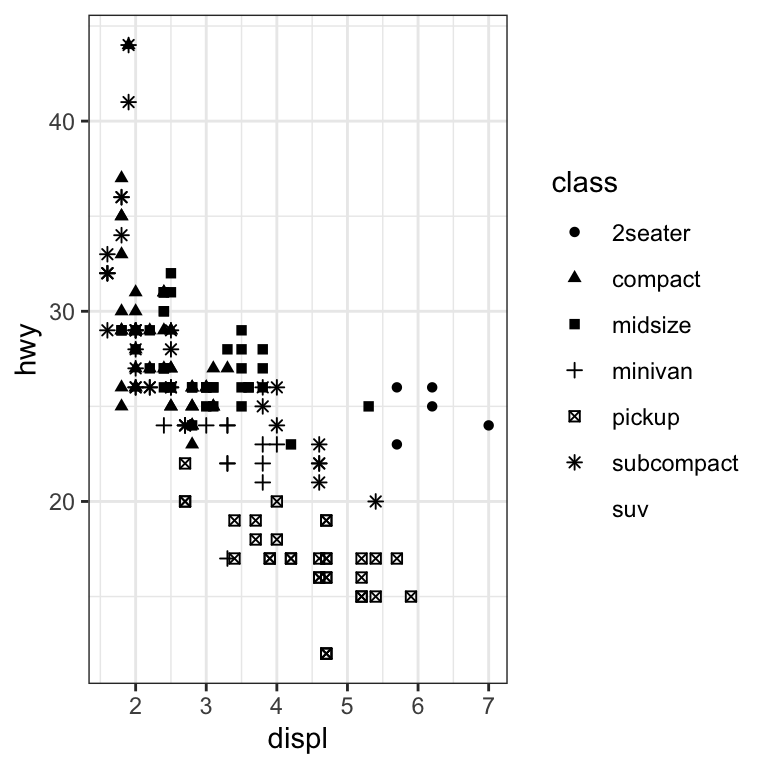

```r
ggplot(data = mpg) +
  geom_point(mapping = aes(x = displ, y = hwy, shape = class))
```

## Notes

- We mapped `class` to the `color` (or `colour` depending on your preference), `alpha`, `shape` aesthetics.
- Sometimes one aesthetic is better than the other! Consider `size` asthetic. What do you think?

## Facets

- For categorical variables **facets** can be useful.
- To facet your plot by a single variable, use `facet_wrap()`.
  - `facet_wrap()` should have a formula; `~` followed by a variable name.

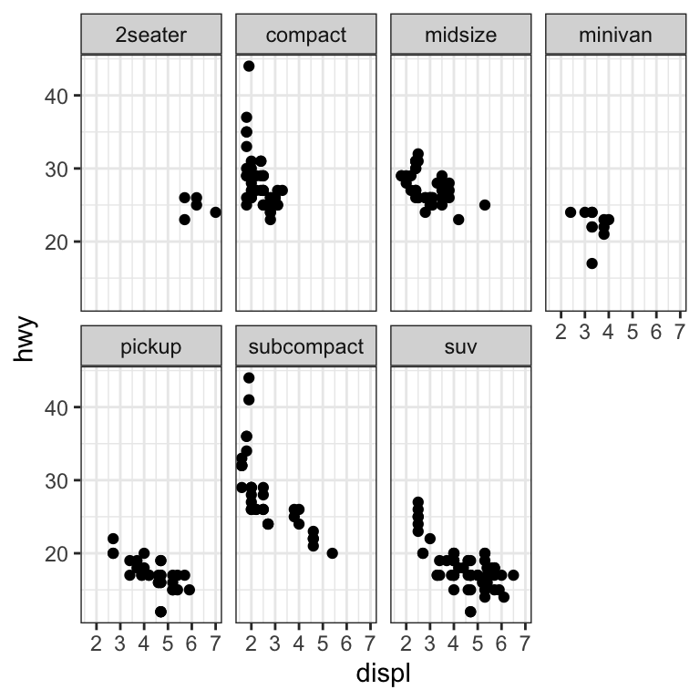

```r
ggplot(data = mpg) +
  geom_point(mapping = aes(x = displ, y = hwy)) +
  facet_wrap(~ class, nrow = 2)
```

## Facets

- To facet your plot on the combination of two variables, add `facet_grid()`.
  - The first argument of facet_grid() is also a formula.

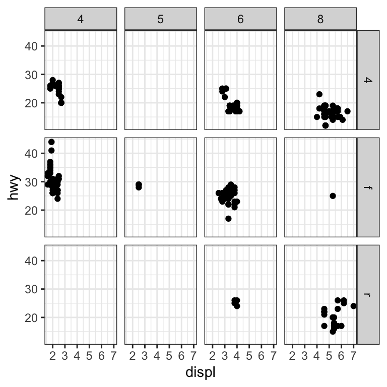

```r
ggplot(data = mpg) +
  geom_point(mapping = aes(x = displ, y = hwy)) +
  facet_grid(drv ~ cyl)
```

[figure not shown]

## Geometric objects

- Both plots
  - contain the same $x$ variable
  - contain the same $y$ variable,
  - describe the same data
- But the plots are not identical–each plot uses a different visual object to represent the data.
- They use different **geoms**.

## `geom`

- A **geom** is the geometrical object that a plot uses to represent data.
  - bar charts use bar geoms
  - line charts use line geoms
  - boxplots use boxplot geoms
  - …
- One uses the point geom, and the other uses the smooth geom.
- To change the geom in your plot, change the geom function that you add to `ggplot()`.

```r
ggplot(data = mpg) +
  geom_point(mapping = aes(x = displ, y = hwy))
```

[output not shown]

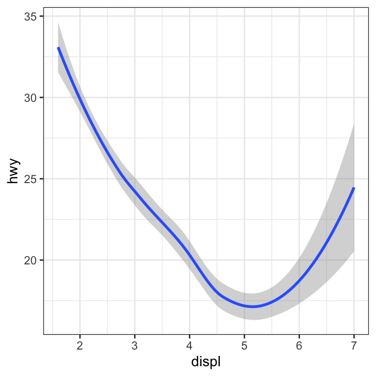

```r
ggplot(data = mpg) +
  geom_smooth(mapping = aes(x = displ, y = hwy))
```

## More on `geom`

- Not every aesthetic works with every geom
  - You could set the shape of a point, but you couldn’t set the “shape” of a line.

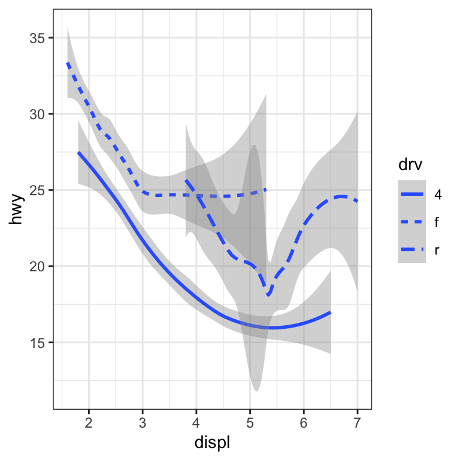

```r
ggplot(data = mpg) +
  geom_smooth(mapping = aes(x = displ, y = hwy,
                            linetype = drv))
```

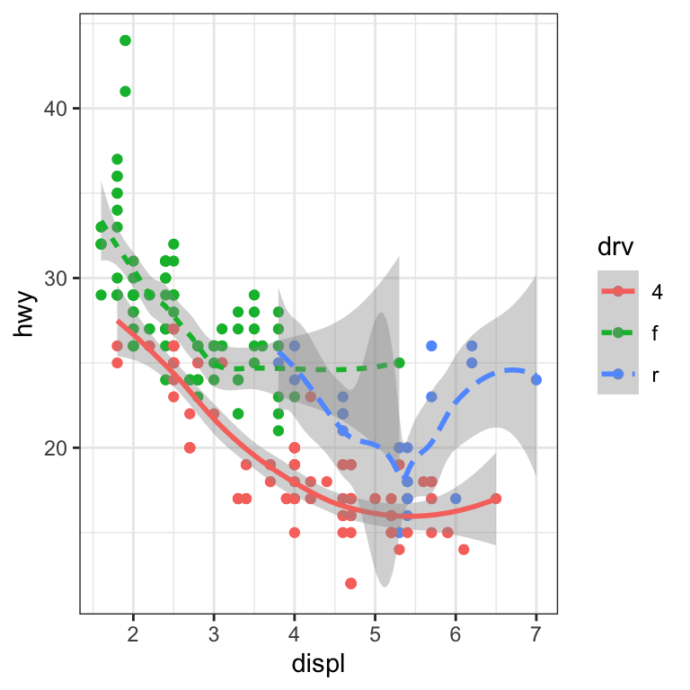

```r
ggplot(data = mpg, mapping = aes(x = displ, y = hwy,
                                 color = drv)) +
  geom_point() +
  geom_smooth(mapping = aes(linetype = drv))
```

## Multiple geoms in the same plot

To display multiple geoms in the same plot, add multiple geom functions to `ggplot()`:

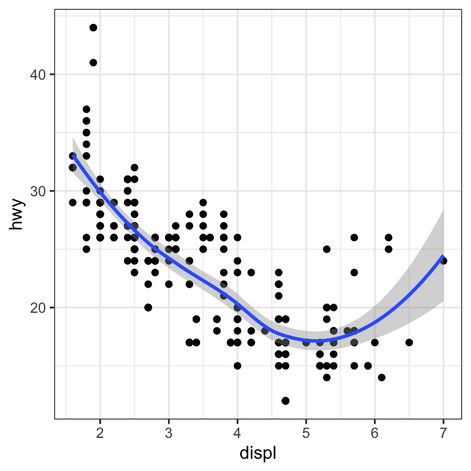

```r
ggplot(data = mpg) +
  geom_point(mapping = aes(x = displ, y = hwy)) +
  geom_smooth(mapping = aes(x = displ, y = hwy))
```

## Global mappings

You can pass a set of mappings to `ggplot()`:

```r
ggplot(data = mpg, mapping = aes(x = displ, y = hwy)) +
  geom_point() +
  geom_smooth()
```

## Local vs Global

- If you place mappings in a geom function, ggplot2 will treat them as local mappings for the layer.
- These mappings will extend or overwrite the global mappings *for that layer only*.

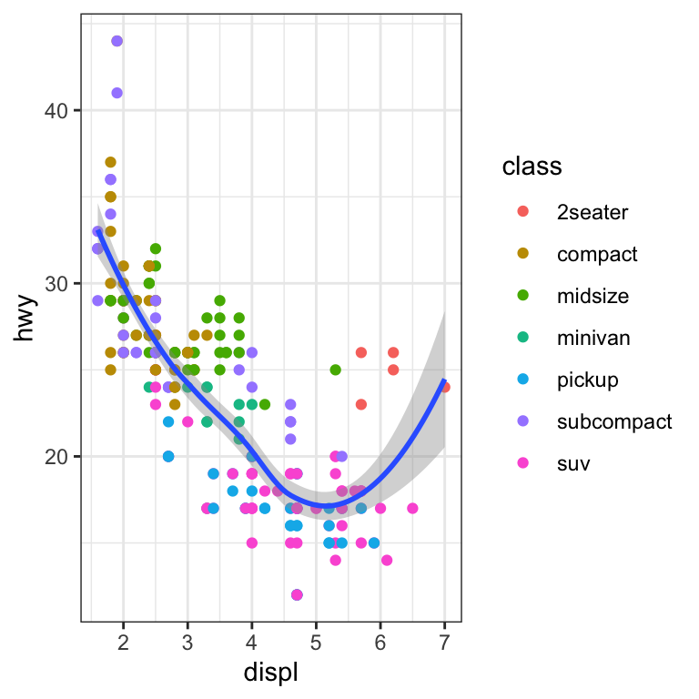

```r
ggplot(data = mpg, mapping = aes(x = displ, y = hwy)) +
  geom_point(mapping = aes(color = class)) +
  geom_smooth()
```

## `joining` different datasets

- You can specify different `data` for each layer; our smooth line displays just a subset of the `mpg` dataset, the subcompact cars.
- The local data argument in `geom_smooth()` overrides the global data argument in `ggplot()` for that layer only.

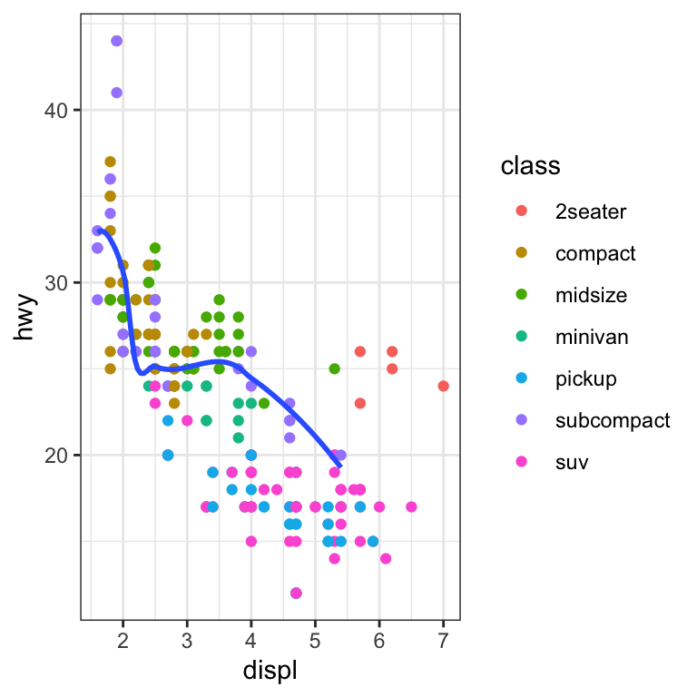

```r
ggplot(data = mpg, mapping = aes(x = displ, y = hwy)) +
  geom_point(mapping = aes(color = class)) +
  geom_smooth(data = filter(mpg, class == "subcompact"),
              se = FALSE)
```

## `diamonds` data set

```r
diamonds
```

```
## # A tibble: 53,940 x 10
##    carat cut       color clarity depth table price     x     y     z
##    <dbl> <ord>     <ord> <ord>   <dbl> <dbl> <int> <dbl> <dbl> <dbl>
##  1 0.23  Ideal     E     SI2      61.5    55   326  3.95  3.98  2.43
##  2 0.21  Premium   E     SI1      59.8    61   326  3.89  3.84  2.31
##  3 0.23  Good      E     VS1      56.9    65   327  4.05  4.07  2.31
##  4 0.290 Premium   I     VS2      62.4    58   334  4.2   4.23  2.63
##  5 0.31  Good      J     SI2      63.3    58   335  4.34  4.35  2.75
##  6 0.24  Very Good J     VVS2     62.8    57   336  3.94  3.96  2.48
##  7 0.24  Very Good I     VVS1     62.3    57   336  3.95  3.98  2.47
##  8 0.26  Very Good H     SI1      61.9    55   337  4.07  4.11  2.53
##  9 0.22  Fair      E     VS2      65.1    61   337  3.87  3.78  2.49
## 10 0.23  Very Good H     VS1      59.4    61   338  4     4.05  2.39
## # … with 53,930 more rows
```

## `diamonds` data set

- Dataset comes in ggplot2 and contains information about ~54,000 diamonds
  - `price`, `carat`, `color`, `clarity`, and `cut`.
- More diamonds are available with high quality cuts than with low quality cuts.

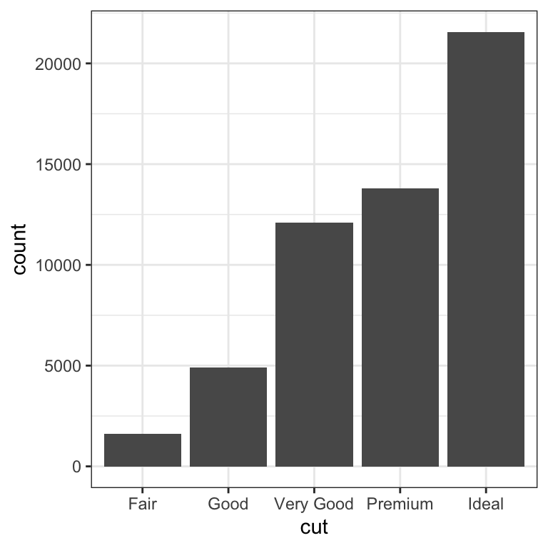

## Thought process

```r
ggplot(data = <DATA>) +
  <GEOM_FUNCTION>(mapping = aes(<MAPPINGS>))
```

- aes?
  - x-axis?: `cut`.
  - y-axis?: `count`.
- geom?:
  - geom_bar
- Do we have `count` in the data set?
  - we need to calculate new values to plot.

## Workflow

## voilà!

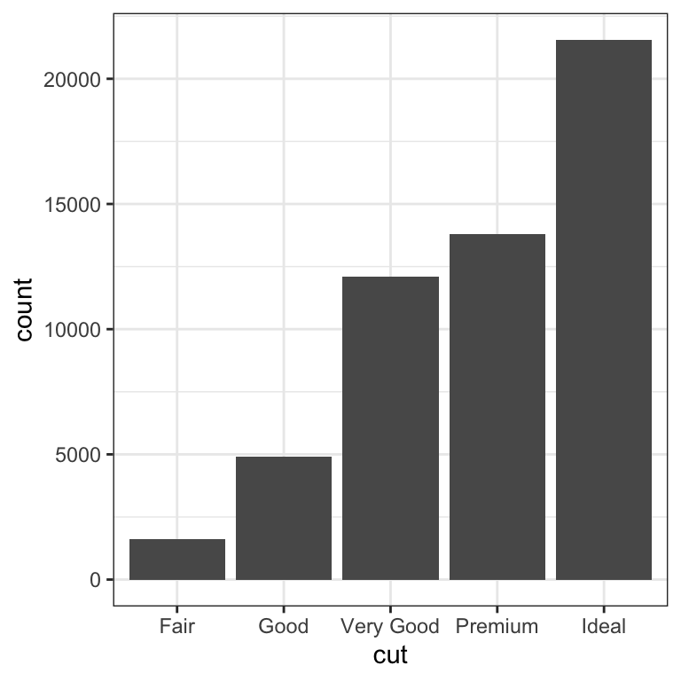

```r
ggplot(data = diamonds) +
  geom_bar(mapping = aes(x = cut))
```

## Saving the plot

```r
test_plot <- ggplot(data = diamonds) +
  geom_bar(mapping = aes(x = cut))
ggsave("test_plot.png") # for png file
ggsave("test_plot.pdf") # for pdf file
```